# R Notebook

# Introduction

As per Kaggle Website:

Ask a home buyer to describe their dream house, and they probably won’t begin with the height of the basement ceiling or the proximity to an east-west railroad. But this playground competition’s dataset proves that much more influences price negotiations than the number of bedrooms or a white-picket fence.

With 79 explanatory variables describing (almost) every aspect of residential homes in Ames, Iowa, this competition challenges you to predict the final price of each home.

Throughout this analysis we will perform feature engineering on predictors one by one in order to try to form the most accurate prediction for house prices. By the end of this analysis the models of ridge, lasso, and cubist will be performed in order to make the final predictions. Of the three, lasso ultimately performed the best and was chosen as the final submission.

# Libraries

```r
library(ggplot2)
library(plyr,include.only = "revalue")
library(dplyr)
library(caret)
library(gridExtra)
library(e1071) #naive bayes
library(corrplot)
library(Metrics)
library(earth)
library(knitr)
library(gt)
options(scipen=999)
```

# Data

There will be two data sets used in this analysis, the train data set and the test data set. The train data set contains 1460 observations and 81 variables and will be used for the data analysis and model building. The test data set will only used in the end to make the final predictions and contains 1459 rows and 80 variables, with the missing variable being the sale price which we are trying to predict.

Id will not be used in this study until casting final predictions so will be dropped.

```r
train <- read.csv("train.csv",stringsAsFactors = FALSE)

gt(head(train))
```

| Id | MSSubClass | MSZoning | LotFrontage | LotArea | Street | Alley | LotShape | LandContour | Utilities | LotConfig | LandSlope | Neighborhood | Condition1 | Condition2 | BldgType | HouseStyle | OverallQual | OverallCond | YearBuilt | YearRemodAdd | RoofStyle | RoofMatl | Exterior1st | Exterior2nd | MasVnrType | MasVnrArea | ExterQual | ExterCond | Foundation | … |
| --- | --- | --- | --- | --- | --- | --- | --- | --- | --- | --- | --- | --- | --- | --- | --- | --- | --- | --- | --- | --- | --- | --- | --- | --- | --- | --- | --- | --- | --- | --- |
| 1 | 60 | RL | 65 | 8450 | Pave | NA | Reg | Lvl | AllPub | Inside | Gtl | CollgCr | Norm | Norm | 1Fam | 2Story | 7 | 5 | 2003 | 2003 | Gable | CompShg | VinylSd | VinylSd | BrkFace | 196 | Gd | TA | PConc | … |
| 2 | 20 | RL | 80 | 9600 | Pave | NA | Reg | Lvl | AllPub | FR2 | Gtl | Veenker | Feedr | Norm | 1Fam | 1Story | 6 | 8 | 1976 | 1976 | Gable | CompShg | MetalSd | MetalSd | None | 0 | TA | TA | CBlock | … |
| 3 | 60 | RL | 68 | 11250 | Pave | NA | IR1 | Lvl | AllPub | Inside | Gtl | CollgCr | Norm | Norm | 1Fam | 2Story | 7 | 5 | 2001 | 2002 | Gable | CompShg | VinylSd | VinylSd | BrkFace | 162 | Gd | TA | PConc | … |
| 4 | 70 | RL | 60 | 9550 | Pave | NA | IR1 | Lvl | AllPub | Corner | Gtl | Crawfor | Norm | Norm | 1Fam | 2Story | 7 | 5 | 1915 | 1970 | Gable | CompShg | Wd Sdng | Wd Shng | None | 0 | TA | TA | BrkTil | … |
| 5 | 60 | RL | 84 | 14260 | Pave | NA | IR1 | Lvl | AllPub | FR2 | Gtl | NoRidge | Norm | Norm | 1Fam | 2Story | 8 | 5 | 2000 | 2000 | Gable | CompShg | VinylSd | VinylSd | BrkFace | 350 | Gd | TA | PConc | … |
| 6 | 50 | RL | 85 | 14115 | Pave | NA | IR1 | Lvl | AllPub | Inside | Gtl | Mitchel | Norm | Norm | 1Fam | 1.5Fin | 5 | 5 | 1993 | 1995 | Gable | CompShg | VinylSd | VinylSd | None | 0 | TA | TA | Wood | … |

```r
test <- read.csv("test.csv",stringsAsFactors = FALSE)

gt(head(test))
```

| Id | MSSubClass | MSZoning | LotFrontage | LotArea | Street | Alley | LotShape | LandContour | Utilities | LotConfig | LandSlope | Neighborhood | Condition1 | Condition2 | BldgType | HouseStyle | OverallQual | OverallCond | YearBuilt | YearRemodAdd | RoofStyle | RoofMatl | Exterior1st | Exterior2nd | MasVnrType | MasVnrArea | ExterQual | ExterCond | Foundation | … |
| --- | --- | --- | --- | --- | --- | --- | --- | --- | --- | --- | --- | --- | --- | --- | --- | --- | --- | --- | --- | --- | --- | --- | --- | --- | --- | --- | --- | --- | --- | --- |
| 1461 | 20 | RH | 80 | 11622 | Pave | NA | Reg | Lvl | AllPub | Inside | Gtl | NAmes | Feedr | Norm | 1Fam | 1Story | 5 | 6 | 1961 | 1961 | Gable | CompShg | VinylSd | VinylSd | None | 0 | TA | TA | CBlock | … |
| 1462 | 20 | RL | 81 | 14267 | Pave | NA | IR1 | Lvl | AllPub | Corner | Gtl | NAmes | Norm | Norm | 1Fam | 1Story | 6 | 6 | 1958 | 1958 | Hip | CompShg | Wd Sdng | Wd Sdng | BrkFace | 108 | TA | TA | CBlock | … |
| 1463 | 60 | RL | 74 | 13830 | Pave | NA | IR1 | Lvl | AllPub | Inside | Gtl | Gilbert | Norm | Norm | 1Fam | 2Story | 5 | 5 | 1997 | 1998 | Gable | CompShg | VinylSd | VinylSd | None | 0 | TA | TA | PConc | … |
| 1464 | 60 | RL | 78 | 9978 | Pave | NA | IR1 | Lvl | AllPub | Inside | Gtl | Gilbert | Norm | Norm | 1Fam | 2Story | 6 | 6 | 1998 | 1998 | Gable | CompShg | VinylSd | VinylSd | BrkFace | 20 | TA | TA | PConc | … |
| 1465 | 120 | RL | 43 | 5005 | Pave | NA | IR1 | HLS | AllPub | Inside | Gtl | StoneBr | Norm | Norm | TwnhsE | 1Story | 8 | 5 | 1992 | 1992 | Gable | CompShg | HdBoard | HdBoard | None | 0 | Gd | TA | PConc | … |
| 1466 | 60 | RL | 75 | 10000 | Pave | NA | IR1 | Lvl | AllPub | Corner | Gtl | Gilbert | Norm | Norm | 1Fam | 2Story | 6 | 5 | 1993 | 1994 | Gable | CompShg | HdBoard | HdBoard | None | 0 | TA | TA | PConc | … |

# NA Values

There exist many variables with at least one missing value in both the train and test sets.

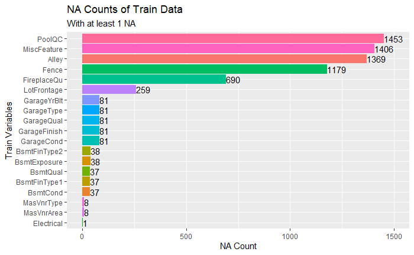

```r
naDF <- data.frame(sapply(train,function(x) sum(is.na(x))))
names(naDF) <- "NA_Count"
naDF$variable <- row.names(naDF)
naDF <- naDF %>%
  filter(NA_Count>0) %>%
  arrange(desc(NA_Count))

ggplot(naDF,aes(x=reorder(variable,NA_Count),y=NA_Count,fill=variable))+
  geom_col()+
  geom_text(aes(label=NA_Count), hjust=0)+
  coord_flip()+
  theme(legend.position = "none")+
  labs(title="NA Counts of Train Data",
       subtitle = "With at least 1 NA")+
  ylab("NA Count")+
  xlab("Train Variables")+
  ylim(0,1500)
```

## Known NA Values

Most of the variables that contain NA values are variables where the NA value is known. For example, the Alley variable replaces the level of “none” with NA and the Basement Quality variable replaces the level of “no basement” with NA.

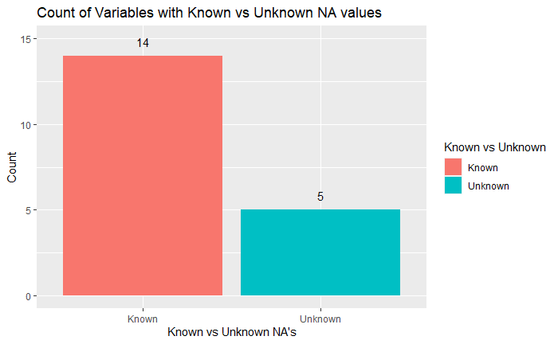

```r
naDF <- naDF %>%
  mutate(knownMissing=ifelse(variable %in% c("Alley","BsmtQual","BsmtCond","BsmtExposure","BsmtFinType1","BsmtFinType2","FireplaceQu","GarageType","GarageFinish","GarageQual","GarageCond","PoolQC","Fence","MiscFeature"),"Known","Unknown"))

ggplot(naDF,aes(x=as.factor(knownMissing),fill=knownMissing))+
  geom_bar()+
  geom_text(stat="count",aes(label=..count..), vjust=-1)+
  xlab("Known vs Unknown NA's")+
  ylab("Count")+
  labs(title="Count of Variables with Known vs Unknown NA values")+
  guides(fill=guide_legend(title="Known vs Unknown"))+
  ylim(0,15)
```

The fourteen variables that have known missing values are Alley, Basement Quality, Basement Condition, Basement Exposure, Basement Finish Type1, Basement Finish Type2, Fire Place Quality, Garage Type, Garage Finish, Garage Quality, Garage Condition, Pool Quality, Fence, and Miscellaneous. The appropriate values will all be added to the train data now to replace the known NA values.

```r
train[is.na(train$Alley),"Alley"] <- "noAccess"

for(name in c("BsmtQual","BsmtCond","BsmtExposure","BsmtFinType1","BsmtFinType2")){
  train[is.na(train[,name]),name] <- "none"
}

train[is.na(train$FireplaceQu),"FireplaceQu"] <- "none"

for(name in c("GarageType","GarageFinish","GarageQual","GarageCond")){
  train[is.na(train[,name]),name] <- "none"
}

train[is.na(train$PoolQC),"PoolQC"] <- "noPool"

train[is.na(train$Fence),"Fence"] <- "noFence"

train[is.na(train$MiscFeature),"MiscFeature"] <- "none"
```

The same will be done for the test set.

```r
test[is.na(test$Alley),"Alley"] <- "noAccess"

for(name in c("BsmtQual","BsmtCond","BsmtExposure","BsmtFinType1","BsmtFinType2")){
  test[is.na(test[,name]),name] <- "none"
}

test[is.na(test$FireplaceQu),"FireplaceQu"] <- "none"

for(name in c("GarageType","GarageFinish","GarageQual","GarageCond")){
  test[is.na(test[,name]),name] <- "none"
}

test[is.na(test$PoolQC),"PoolQC"] <- "noPool"

test[is.na(test$Fence),"Fence"] <- "noFence"

test[is.na(test$MiscFeature),"MiscFeature"] <- "none"
```

## Unknown NA Values

Only five variables have remaining NA values. These values will be calulated in the feature engineering section.

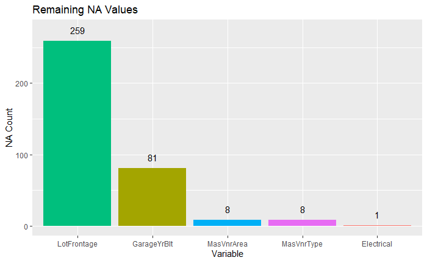

```r
#creating na table
naDF <- data.frame(sapply(train,function(x) sum(is.na(x))))
names(naDF) <- "NA_Count"
naDF$variable <- row.names(naDF)
naDF <- naDF %>%
  select(variable,NA_Count) %>%
  filter(NA_Count>0)

ggplot(naDF,aes(x=variable,y=NA_Count,fill=variable))+
  geom_col(aes(x=reorder(variable,desc(NA_Count))))+
  geom_text(aes(label=NA_Count), vjust=-1)+
  xlab("Variable")+
  ylab("NA Count")+
  labs(title="Remaining NA Values")+
  theme(legend.position = "none")+
  ylim(0,275)
```

```r
NA
NA
```

# Data Analysis

## ggplot Custom Functions

ggplot function for continuous data:

```r
#train with complete observations only

numericggplot <- function(variable){
  histo <- ggplot(train,aes(x=train[,variable]))+
    geom_histogram()+
    xlab(variable)+
    theme(axis.text=element_text(size=14),
          axis.title=element_text(size=14,face="bold"))+
    labs(title=variable)


  scattero <- ggplot(train,aes(x=train[,variable],y=SalePrice))+
    geom_point()+
    geom_smooth(method = "lm", se=FALSE, color="black")+
    xlab(variable)+
    ylab("SalePrice")+
    theme(axis.text=element_text(size=14),
          axis.title=element_text(size=14,face="bold"))+
    labs(title=variable)

grid.arrange(histo,scattero,ncol=2)
}
```

ggplot function for discrete data:

```r
discreteggplot <- function(name){
    discretePlot <- ggplot(train,aes(x=train[,name]))+
    geom_bar()+xlab(name)

discreteBox <- ggplot(train,aes(x=as.character(train[,name]),y=SalePrice))+
    geom_boxplot()+xlab(name)

grid.arrange(discretePlot,discreteBox,ncol=2)
}
```

## Dependent Variable

The dependent variable we are trying to predict is SalePrice. **SalePrice** represents the prices of houses in Ames, Iowa. It exists in the train data set, but not in the test data set. It is skewed to the right with some very high trailing values.

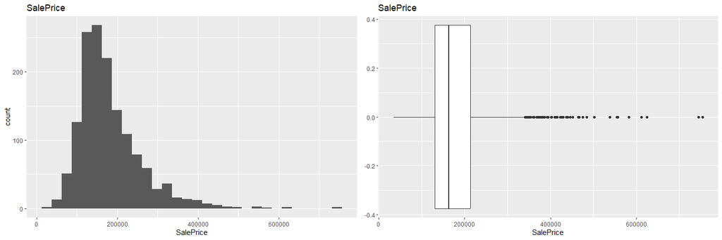

```r
salePriceHisto <- ggplot(train,aes(x=SalePrice))+
  geom_histogram()+
  labs(title="SalePrice")

salePriceBox <- ggplot(train,aes(x=SalePrice))+
  geom_boxplot()+
  labs(title="SalePrice")

grid.arrange(salePriceHisto,salePriceBox,ncol=2)
```

By applying the log transformation the sale price becomes normally distributed.

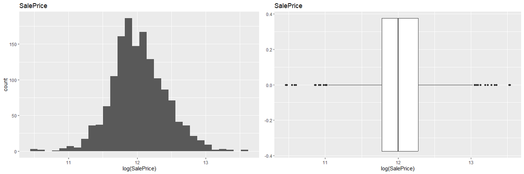

```r
salePriceHistoLog <- ggplot(train,aes(x=log(SalePrice)))+
  geom_histogram()+
  labs(title="SalePrice")+
  xlab("log(SalePrice)")

salePriceBoxLog <- ggplot(train,aes(x=log(SalePrice)))+
  geom_boxplot()+
  labs(title="SalePrice")+
  xlab("log(SalePrice)")

grid.arrange(salePriceHistoLog,salePriceBoxLog,ncol=2)
```

## Numeric Predictors

For numeric variables in general if it is an ordered predictor we will make it an integer and if not we will make it a double. This will make the pre-processing (scaling, centering…) much easier.

### Lot Frontage and Area

**LotFrontage:** Linear feet of street connected to a property. There appears to be two outliers with lot frontage above 300 including observations 935 and 1299.

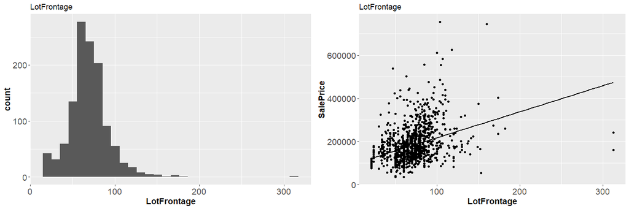

```r
numericggplot("LotFrontage")
```

```r
kable(train %>% filter(LotFrontage>300))
```

| Id | MSSubClass | MSZoning | LotFrontage | LotArea | Street | Alley | LotShape | LandContour | Utilities | LotConfig | LandSlope | Neighborhood | Condition1 | Condition2 | BldgType | HouseStyle | OverallQual | OverallCond | YearBuilt | YearRemodAdd | RoofStyle | RoofMatl | Exterior1st | Exterior2nd | MasVnrType | MasVnrArea | ExterQual | ExterCond | Foundation | … |
| --- | --- | --- | --- | --- | --- | --- | --- | --- | --- | --- | --- | --- | --- | --- | --- | --- | --- | --- | --- | --- | --- | --- | --- | --- | --- | --- | --- | --- | --- | --- |
| 935 | 20 | RL | 313 | 27650 | Pave | noAccess | IR2 | HLS | AllPub | Inside | Mod | NAmes | PosA | Norm | 1Fam | 1Story | 7 | 7 | 1960 | 2007 | Flat | Tar&Grv | Wd Sdng | Wd Sdng | None | 0 | TA | TA | CBlock | … |
| 1299 | 60 | RL | 313 | 63887 | Pave | noAccess | IR3 | Bnk | AllPub | Corner | Gtl | Edwards | Feedr | Norm | 1Fam | 2Story | 10 | 5 | 2008 | 2008 | Hip | ClyTile | Stucco | Stucco | Stone | 796 | Ex | TA | PConc | … |

**LotArea:** Lot size in square feet. Contains only four values above 100,000 including observations 250, 314, 336, and 707.

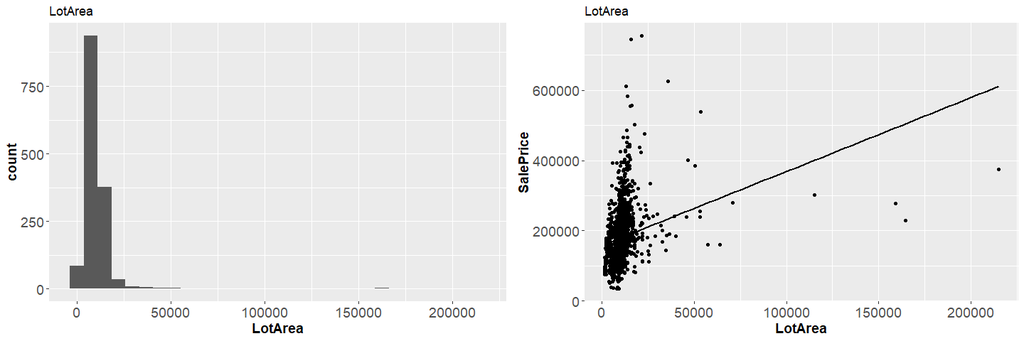

```r
numericggplot("LotArea")
```

```r
kable(train[train$LotArea>100000,])
```

|  | Id | MSSubClass | MSZoning | LotFrontage | LotArea | Street | Alley | LotShape | LandContour | Utilities | LotConfig | LandSlope | Neighborhood | Condition1 | Condition2 | BldgType | HouseStyle | OverallQual | OverallCond | YearBuilt | YearRemodAdd | RoofStyle | RoofMatl | Exterior1st | Exterior2nd | MasVnrType | MasVnrArea | ExterQual | ExterCond | … |
| --- | --- | --- | --- | --- | --- | --- | --- | --- | --- | --- | --- | --- | --- | --- | --- | --- | --- | --- | --- | --- | --- | --- | --- | --- | --- | --- | --- | --- | --- | --- |
| 250 | 250 | 50 | RL | NA | 159000 | Pave | noAccess | IR2 | Low | AllPub | CulDSac | Sev | ClearCr | Norm | Norm | 1Fam | 1.5Fin | 6 | 7 | 1958 | 2006 | Gable | CompShg | Wd Sdng | HdBoard | BrkCmn | 472 | Gd | TA | … |
| 314 | 314 | 20 | RL | 150 | 215245 | Pave | noAccess | IR3 | Low | AllPub | Inside | Sev | Timber | Norm | Norm | 1Fam | 1Story | 7 | 5 | 1965 | 1965 | Hip | CompShg | BrkFace | BrkFace | None | 0 | TA | TA | … |
| 336 | 336 | 190 | RL | NA | 164660 | Grvl | noAccess | IR1 | HLS | AllPub | Corner | Sev | Timber | Norm | Norm | 2fmCon | 1.5Fin | 5 | 6 | 1965 | 1965 | Gable | CompShg | Plywood | Plywood | None | 0 | TA | TA | … |
| 707 | 707 | 20 | RL | NA | 115149 | Pave | noAccess | IR2 | Low | AllPub | CulDSac | Sev | ClearCr | Norm | Norm | 1Fam | 1Story | 7 | 5 | 1971 | 2002 | Gable | CompShg | Plywood | Plywood | Stone | 351 | TA | TA | … |

$\textbf{Pick the next tab in order to see other variables.}$

### Misc Value

**MiscVal:** Value of miscellaneous features. Most have a value of zero inferring no miscellaneous feature. Given that the value is not zero, the average miscellaneous value is 1221.

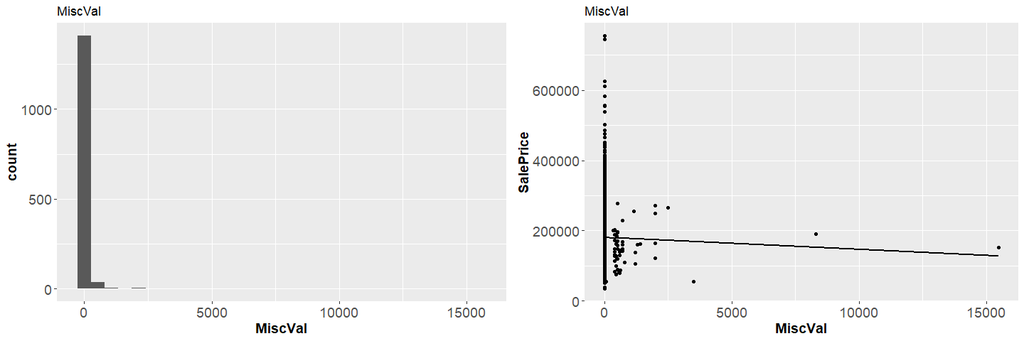

```r
numericggplot("MiscVal")
```

```r
miscValTable <- as.data.frame(table(train$MiscVal))
names(miscValTable) <- c("value","frequency")
kable(miscValTable)
```

| value | frequency |
| --- | --- |
| 0 | 1408 |
| 54 | 1 |
| 350 | 1 |
| 400 | 11 |
| 450 | 4 |
| 480 | 2 |
| 500 | 8 |
| 560 | 1 |
| 600 | 4 |
| 620 | 1 |
| 700 | 5 |
| 800 | 1 |
| 1150 | 1 |
| 1200 | 2 |
| 1300 | 1 |
| 1400 | 1 |
| 2000 | 4 |
| 2500 | 1 |
| 3500 | 1 |
| 8300 | 1 |
| 15500 | 1 |

```r
#average price of misc. value given not 0
round(mean(train[!is.na(train$MiscVal) & train$MiscVal!=0,"MiscVal"]),1)
```

```
[1] 1221
```

$\textbf{Pick the next tab in order to see other variables.}$

### Year Built, Year Remodeled, Garage Year Built

**YearBuilt:** Original construction date. The newer the house, the higher the house prices are. However, there are a couple houses built before 1900 that are very expensize. Investigating we can see that all four of these houses had a recent remodel. A predictor will be added for houses that have a remodel year that is not equal to the year the house was built.

|  | YearBuilt | YearRemodAdd | SalePrice |
| --- | --- | --- | --- |
| 186 | 1892 | 1993 | 475000 |
| 305 | 1880 | 2002 | 295000 |
| 584 | 1893 | 2000 | 325000 |
| 748 | 1880 | 2003 | 265979 |

**YearRemodAdd:** Remodel date (same as construction date if no remodeling or additions). Fifty-two percent of houses did not have a remodel.

```r
print(paste(round(sum(train$YearRemodAdd==train$YearBuilt)/nrow(train)*100,0),"% of houses did not have a remodel."))
```

```
[1] "52 % of houses did not have a remodel."
```

**GarageYrBlt:** Year garage was built. Most of the time the garage was built when the house was built. There will be an added feature later on to depict whether or not the garage was added after the house was built. There is a clear typo with garage year built after 2200. This value will be replaced with the year that the house was built in the feature engineering section.

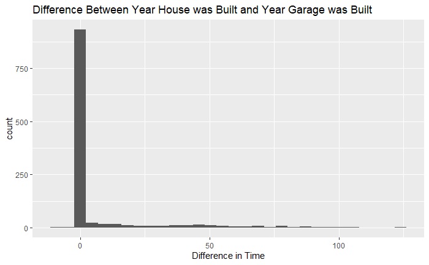

$\textbf{Pick the next tab in order to see other variables.}$

### Garage Cars and Area

**GarageCars:** Size of garage in car capacity.

**GarageArea:** Size of garage in square feet.

There exists a strong correlation between garage cars and garage area which makes sense. One of the predictors will likely be dropped later on.

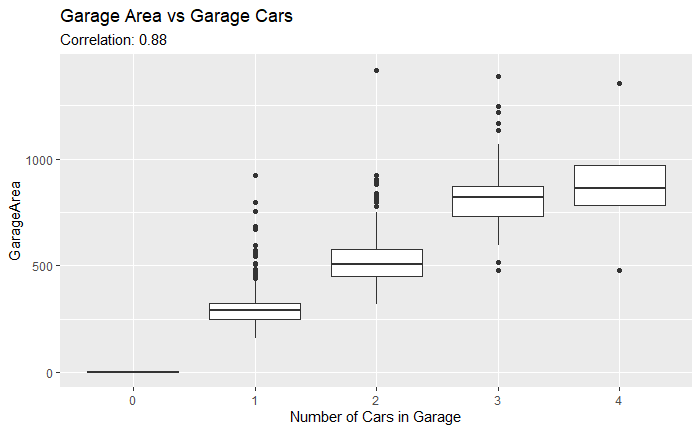

$\textbf{Pick the next tab in order to see other variables.}$

### MasVnrArea and MasVnrType

**MasVnrArea:** Masonry veneer area in square feet. Most of the values are zero.

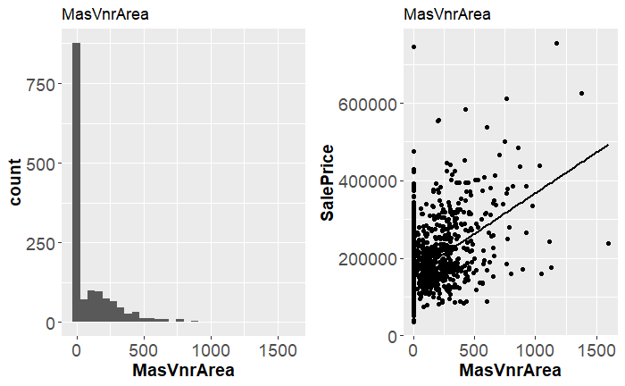

```r
numericggplot("MasVnrArea")
```

```r
kable(train %>% filter(MasVnrArea==0 & !MasVnrType=="None") %>% select(MasVnrArea,MasVnrType))
```

| MasVnrArea | MasVnrType |
| --- | --- |
| 0 | BrkFace |
| 0 | Stone |

```r
NA
```

**MasVnrType:** Masonry veneer type. There are two observations that have a masonry vaneer type listed, but have a masonry veneer area of zero. There are also five cases where the Masonry Vaneer Type is none but the Masonry Vaneer Area is not zero. These will be addressed in feature engineering section.

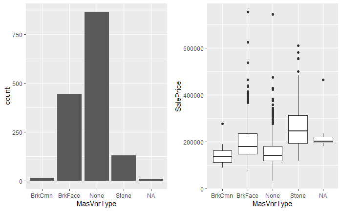

```r
discreteggplot("MasVnrType")
```

```r
kable(train %>% filter(MasVnrArea==0 & !MasVnrType=="None") %>% select(MasVnrArea,MasVnrType))
```

| MasVnrArea | MasVnrType |
| --- | --- |
| 0 | BrkFace |
| 0 | Stone |

```r
train[complete.cases(train$MasVnrType),] %>% group_by(MasVnrType) %>% summarize(medianMasVnrArea=median(MasVnrArea,na.rm=TRUE))
```

| MasVnrType | medianMasVnrArea |
| --- | --- |
| BrkCmn | 192.0 |
| BrkFace | 202.0 |
| None | 0.0 |
| Stone | 206.5 |

```r
kable(train %>% filter(MasVnrArea!=0 & MasVnrType=="None") %>% select(MasVnrArea,MasVnrType))
```

| MasVnrArea | MasVnrType |
| --- | --- |
| 288 | None |
| 1 | None |
| 1 | None |
| 344 | None |
| 312 | None |

$\textbf{Pick the next tab in order to see other variables.}$

### Basement Area Predictors

**BsmtFinSF1:** Type 1 finish square feet. Observation 1299 is an outlier with the basement type1 square feet being above 3000.

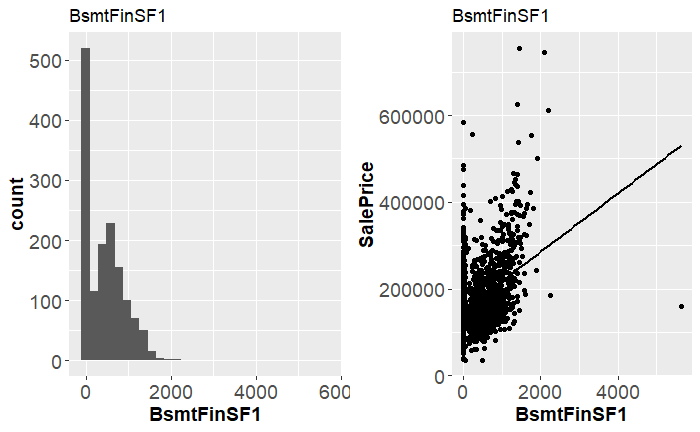

```r
numericggplot("BsmtFinSF1")
```

```r
kable(train %>% filter(BsmtFinSF1>3000) %>% select(Id,BsmtFinSF1,BsmtFinSF2,BsmtUnfSF,TotalBsmtSF))
```

| Id | BsmtFinSF1 | BsmtFinSF2 | BsmtUnfSF | TotalBsmtSF |
| --- | --- | --- | --- | --- |
| 1299 | 5644 | 0 | 466 | 6110 |

```r
NA
```

**BsmtFinSF2:** Type 2 finished square feet.

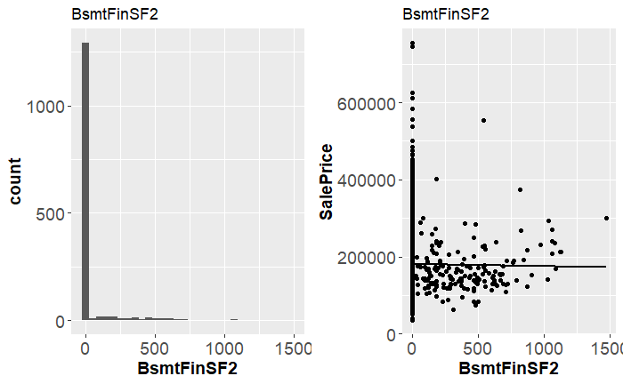

```r
numericggplot("BsmtFinSF2")
```

**BsmtUnfSF:** Unfinished square feet of basement area.

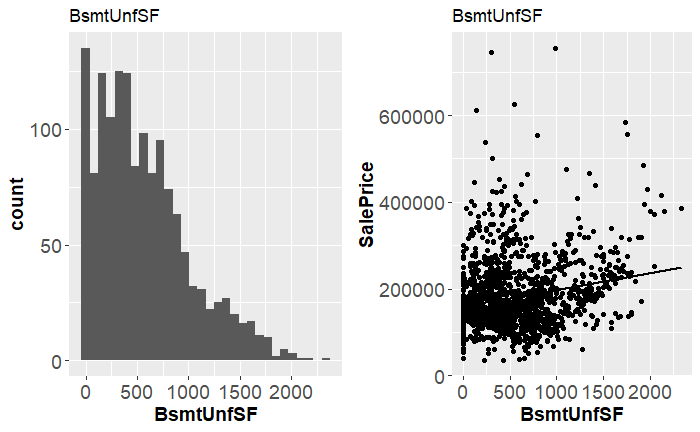

```r
numericggplot("BsmtUnfSF")
```

**TotalBsmtSF:** Total square feet of basement area. Is the same as the sum of finished square feet 1, finished square feet 2, and unfinished square feet. There is one outlier with a total basement square feet above 6000 which is observation 1299. However, the sum of finished square feet 1, finished square feet 2, and unfinished square feet is equal to the total sum of square feet basement area for each observation meaning no typo errors.

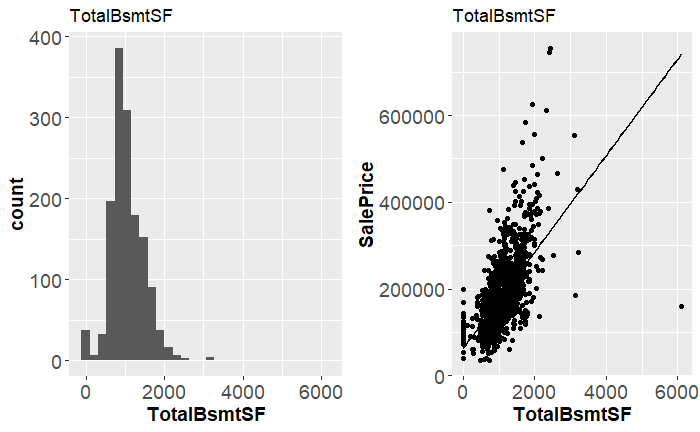

```r
numericggplot("TotalBsmtSF")
```

```r
sum(train$TotalBsmtSF!=train$BsmtFinSF1+train$BsmtFinSF2+train$BsmtUnfSF)
```

```
[1] 0
```

$\textbf{Pick the next tab in order to see other variables.}$

**X1stFlrSF:** First Floor square feet.

```r
numericggplot("X1stFlrSF")
```

**X2ndFlrSF:** Second floor square feet.

```r
numericggplot("X2ndFlrSF")
```

**LowQualFinSF:** Low quality finished square feet (all floors).

```r
numericggplot("LowQualFinSF")
```

**GrLivArea:** Above grade (ground) living area square feet.

```r
numericggplot("GrLivArea")
sum(combined$X1stFlrSF+combined$X2ndFlrSF+combined$LowQualFinSF==combined$GrLivArea)/nrow(combined)

kable(combined[combined$GrLivArea>5000,])
```

$\textbf{Pick the next tab in order to see other variables.}$

### Number of Bathrooms

**BsmtFullBath:** Basement full bathrooms.

**BsmtHalfBath:** Basement half bathrooms.

**FullBath:** Full bathrooms above grade.

**HalfBath:** Half baths above grade.

```r
#BsmtFullBath plot
discreteggplot("BsmtFullBath")
#BsmtHalfBath plot
discreteggplot("BsmtHalfBath")
#FullBath
discreteggplot("FullBath")
#HalfBath
discreteggplot("HalfBath")
```

There is no variable for the total bathrooms in a house. This will be added later on in the feature engineering section.

$\textbf{Pick the next tab in order to see other variables.}$

### Bedrooms, Kitchens, Total Rooms

**BedroomAbvGr:** Bedrooms above grade (does NOT include basement bedrooms).

**KitchenAbvGr:** Kitchens above grade.

**TotRmsAbvGrd:** Total rooms above grade (does not include bathrooms).

The total rooms does not equal bedrooms + kitchens. A variable can be made later to address rooms that are not kitchens or bedrooms.

```r
ggplot(combined[!is.na(combined$SalePrice),],aes(x=as.factor(BedroomAbvGr),y=SalePrice))+geom_boxplot()+xlab("Bedrooms Above Ground")

ggplot(combined[!is.na(combined$SalePrice),],aes(x=as.factor(KitchenAbvGr),y=SalePrice))+geom_boxplot()+xlab("Kitchens Above Ground")

ggplot(combined[!is.na(combined$SalePrice),],aes(x=as.factor(TotRmsAbvGrd),y=SalePrice))+geom_boxplot()+xlab("Total Rooms Above Ground")
```

$\textbf{Pick the next tab in order to see other variables.}$

### Fireplaces

```r
discreteggplot("Fireplaces")
```

$\textbf{Pick the next tab in order to see other variables.}$

### Porch Variables

**OpenPorchSF:** Open porch area in square feet.

**EnclosedPorch:** Enclosed porch area in square feet.

**X3SsnPorch:** Three season porch area in square feet.

**ScreenPorch:** Screen porch area in square feet.

A predictor will be made later for whether or not a house has a porch.

```r
numericggplot("OpenPorchSF")
numericggplot("EnclosedPorch")
numericggplot("X3SsnPorch")
numericggplot("ScreenPorch")
```

**WoodDeckSF:** Wood deck area in square feet.

```r
numericggplot("WoodDeckSF")
```

$\textbf{Pick the next tab in order to see other variables.}$

### Pool Area

**PoolArea:** Pool area in square feet. When the quality of the pool is labeled as “noPool”, the pool area should be zero. This is not the case for three observations. When comparing the size of the pool to the quality there seems to be no pattern. The values of quality for these observations will be filled in with good, which is the middle value of pool quality.

```r
numericggplot("PoolArea")

#checking if relation between size and quality
combined[combined$PoolArea!=0,c("PoolArea","PoolQC")] %>% arrange(PoolArea)

#setting the three pool quality values from nopool to Gd
combined[combined$PoolQC=="noPool" & combined$PoolArea!=0,c("PoolQC")] <- "Gd"
```

## Converting to Double

Will make pre-processing section easier.

```r
for(name in c("LotFrontage","LotArea","YearBuilt","YearRemodAdd","MasVnrArea","BsmtFinSF1","BsmtFinSF2","BsmtUnfSF","TotalBsmtSF","X1stFlrSF","X2ndFlrSF","LowQualFinSF","GrLivArea","BsmtFullBath","BsmtHalfBath","FullBath","HalfBath","BedroomAbvGr","KitchenAbvGr","TotRmsAbvGrd","Fireplaces","GarageYrBlt","GarageCars","GarageArea","WoodDeckSF","OpenPorchSF","EnclosedPorch","X3SsnPorch","ScreenPorch","PoolArea","MiscVal")){
  combined[,name] <- as.double(combined[,name])
}
```

## Date/Time Predictors

**MoSold:** Month Sold (MM).

**YrSold:** Year Sold (YYYY).

Most houses seem to sell in the summer months but the average house price per month sold seems pretty even. There is no clear trend upwards or downwards per month over the five years.

```r
ggplot(combined,aes(x=as.character(MoSold)))+
  geom_bar()+
  scale_x_discrete(limits=seq(1,12))+
  xlab("Months")

ggplot(combined[!is.na(combined$SalePrice),],aes(x=as.character(MoSold),y=SalePrice))+
  geom_boxplot()+
  scale_x_discrete(limits=seq(1,12))+
  xlab("Months")
```

From the previous charts we can see the end of the range of observations is in August 2010, which explains why 2010 has the least number of houses sold. There appears to be a gradual decrease in the median price of a house sold from 2006 to 2010. Both month sold and year sold will be converted to character predictors as there is no apparent ordering of sale price within them.

```r
discreteggplot("YrSold")

combined$YrSold <- as.character(combined$YrSold)
combined$MoSold <- as.character(combined$MoSold)
```

## Ordered Predictors

### Overall Quality

**OverallQual:** Rates the overall material and finish of the house

- 10 Very Excellent
- 9 Excellent
- 8 Very Good
- 7 Good
- 6 Above Average
- 5 Average
- 4 Below Average
- 3 Fair
- 2 Poor
- 1 Very Poor

There is a clear increase in the sale of house prices as the quality of the house increases.

```r
overallqualBar <- ggplot(combined,aes(x=OverallQual))+
  geom_bar()+
  scale_x_discrete(limits=seq(1,10))+
  xlab("Overall Quality")

overallqualBox <- ggplot(combined[!is.na(combined$SalePrice),],aes(x=as.character(OverallQual),y=SalePrice))+
  geom_boxplot()+
  scale_x_discrete(limits=seq(1,10))+
  xlab("Overall Quality")

grid.arrange(overallqualBar,overallqualBox,ncol=2)
```

$\textbf{Pick the next tab in order to see other variables.}$

### Overall Condition

**OverallCond:** Rates the overall condition of the house.

- 10 Very Excellent
- 9 Excellent
- 8 Very Good
- 7 Good
- 6 Above Average
- 5 Average
- 4 Below Average
- 3 Fair
- 2 Poor
- 1 Very Poor

There is one outlier with overall condition 2 and another at overall condition 6 (observations 379 and 692).

```r
ggplot(combined[!is.na(combined$SalePrice),],aes(x=as.character(OverallCond),y=SalePrice))+
  geom_boxplot()+
  scale_x_discrete(limits=seq(1,10))+
  xlab("Overall Condition")

kable(combined[combined$OverallCond==2 & combined$SalePrice>350000 & !is.na(combined$SalePrice),])

kable(combined[combined$OverallCond==6 & combined$SalePrice>600000 & !is.na(combined$SalePrice),])
```

$\textbf{Pick the next tab in order to see other variables.}$

### External Quality and Condition

**ExterQual:** Evaluates the quality of the material on the exterior.

- Ex Excellent
- Gd Good
- TA Average/Typical
- Fa Fair
- Po Poor

**ExterCond:** Evaluates the present condition of the material on the exterior.

- Ex Excellent
- Gd Good
- TA Average/Typical
- Fa Fair
- Po Poor

External quality and external condition will both be made into ordered predictors.

```r
noNone <- c('Po' = 0, 'Fa' = 1, 'TA' = 2, 'Gd' = 3, 'Ex' = 4)
#making into ordered
combined$ExterQual<-as.integer(revalue(combined$ExterQual, noNone))
table(train$ExterQual)

combined$ExterCond<-as.integer(revalue(combined$ExterCond, noNone))

discreteggplot("ExterQual")
discreteggplot("ExterCond")
```

$\textbf{Pick the next tab in order to see other variables.}$

### Basement Quality and Condition

**BsmtQual:** Evaluates the height of the basement.

- Ex Excellent (100+ inches)
- Gd Good (90-99 inches)
- TA Typical (80-89 inches)
- Fa Fair (70-79 inches)
- Po Poor (<70 inches
- NA No Basement

**BsmtCond:** Evaluates the general condition of the basement.

- Ex Excellent
- Gd Good
- TA Typical - slight dampness allowed
- Fa Fair - dampness or some cracking or settling
- Po Poor - Severe cracking, settling, or wetness
- NA No Basement

Both basement quality and basement condition will be made into ordered predictors.

```r
table(combined$BsmtCond)
withNone <-c('none' = 0, 'Po' = 1, 'Fa' = 2, 'TA' = 3, 'Gd' = 4, 'Ex' = 5)

combined$BsmtQual <- as.integer(revalue(combined$BsmtQual,withNone))
combined$BsmtCond <- as.integer(revalue(combined$BsmtCond,withNone))

discreteggplot("BsmtQual")
discreteggplot("BsmtCond")
```

$\textbf{Pick the next tab in order to see other variables.}$

### Kitchen Quality

**KitchenQual:** Kitchen quality.

- Ex Excellent
- Gd Good
- TA Typical/Average
- Fa Fair
- Po Poor

Kitchen quality made into ordered.

```r
combined$KitchenQual <- as.integer(revalue(combined$KitchenQual,noNone))

discreteggplot("KitchenQual")
```

$\textbf{Pick the next tab in order to see other variables.}$

### Fireplace Quality

**FireplaceQu:** Fireplace quality.

- Ex Excellent - Exceptional Masonry Fireplace
- Gd Good - Masonry Fireplace in main level
- TA Average - Prefabricated Fireplace in main living area or Masonry Fireplace in basement
- Fa Fair - Prefabricated Fireplace in basement
- Po Poor - Ben Franklin Stove
- NA No Fireplace

Converted to ordered.

```r
combined$FireplaceQu <- as.integer(revalue(combined$FireplaceQu,withNone))
discreteggplot("FireplaceQu")
```

$\textbf{Pick the next tab in order to see other variables.}$

### Garage Quality and Condition

**GarageQual:** Garage quality.

- Ex Excellent
- Gd Good
- TA Typical/Average
- Fa Fair
- Po Poor
- NA No Garage

**GarageCond:** Garage condition.

- Ex Excellent
- Gd Good
- TA Typical/Average
- Fa Fair
- Po Poor
- NA No Garage

Converting both to ordered.

```r
combined$GarageQual <- as.integer(revalue(combined$GarageQual,withNone))
combined$GarageCond <- as.integer(revalue(combined$GarageCond,withNone))

discreteggplot("GarageQual")
discreteggplot("GarageCond")
```

$\textbf{Pick the next tab in order to see other variables.}$

### Pool Quality

**PoolQC:** Pool quality.

- Ex Excellent
- Gd Good
- TA Average/Typical
- Fa Fair
- NA No Pool

Pool quality made into ordered. Can make feature later for whether or not a house has a pool.

```r
poolOrdered <- c('noPool'=0,'Fa'=1,'TA'=2,'Gd'=3,'Ex'=4)
combined$PoolQC <- as.integer(revalue(combined$PoolQC,poolOrdered))

print(paste("Only ",sum(combined$PoolQC!=0)," of",nrow(combined)," houses have a pool."))
discreteggplot("PoolQC")
```

$\textbf{Pick the next tab in order to see other variables.}$

### Street

**Street:** Type of road access to property.

- Grvl Gravel
- Pave Paved

Made into ordered predictor with paved being superior to gravel.

```r
combined[combined$Street=="Grvl","Street"] <- 0
combined[combined$Street=="Pave","Street"] <- 1
combined$Street <- as.integer(combined$Street)

discreteggplot("Street")
print(paste("There are only ",sum(combined$Street==0)," houses that have a gravel steet."))
```

$\textbf{Pick the next tab in order to see other variables.}$

### LandSlope

**LandSlope:** Slope of property.

- Gtl Gentle slope
- Mod Moderate Slope
- Sev Severe Slope

Made into ordered with Gtl>Mod>Sev.

```r
#order labeling
combined[combined$LandSlope=="Gtl","LandSlope"] <- 0
combined[combined$LandSlope=="Mod","LandSlope"] <- 1
combined[combined$LandSlope=="Sev","LandSlope"] <- 2

discreteggplot("LandSlope")
```

$\textbf{Pick the next tab in order to see other variables.}$

### Heating quality, Central Air, Electrical

**HeatingQC:** Heating quality and condition.

- Ex Excellent
- Gd Good
- TA Average/Typical
- Fa Fair
- Po Poor

**CentralAir:** Central air conditioning.

- N No
- Y Yes

**Electrical:** Electrical system.

- SBrkr Standard Circuit Breakers & Romex
- FuseA Fuse Box over 60 AMP and all Romex wiring (Average)
- FuseF 60 AMP Fuse Box and mostly Romex wiring (Fair)
- FuseP 60 AMP Fuse Box and mostly knob & tube wiring (poor)
- Mix Mixed

Heating quality, central air, and electrical will all be changed into ordered.

```r
noNone

combined$HeatingQC <- as.integer(revalue(combined$HeatingQC,noNone))

combined$CentralAir <- as.integer(revalue(combined$CentralAir,c('N'=0,'Y'=1)))

combined$Electrical <- as.integer(revalue(combined$Electrical,c('Mix'=0,'FuseP'=1,'FuseF'=2,'FuseA'=3,'SBrkr'=4)))


discreteggplot("HeatingQC")
discreteggplot("CentralAir")
discreteggplot("Electrical")
```

$\textbf{Pick the next tab in order to see other variables.}$

### Masonry Veneer Type

**MasVnrType:** Masonry veneer type.

- BrkCmn Brick Common
- BrkFace Brick Face
- CBlock Cinder Block
- None None
- Stone Stone

Made into ordered predictor with the sequential order of None, Brick Common, Brick Face, and then stone. Cinder block is not in the dataset so it wont be included, not sure where it would rank.

```r
combined$MasVnrType <- as.integer(revalue(combined$MasVnrType,c('None'=0,'BrkCmn'=1,'BrkFace'=2,'Stone'=3)))
discreteggplot("MasVnrType")
```

$\textbf{Pick the next tab in order to see other variables.}$

### Basement Exposure

**BsmtExposure:** Refers to walkout or garden level walls.

- Gd Good Exposure
- Av Average Exposure (split levels or foyers typically score average or above)
- Mn Mimimum Exposure
- No No Exposure
- NA No Basement

Made into ordered based on level of exposure.

```r
table(combined$BsmtExposure)
combined$BsmtExposure <- as.integer(revalue(combined$BsmtExposure,c('none'=0,'No'=1,'Mn'=2,'Av'=3,'Gd'=4)))
discreteggplot("BsmtExposure")
```

$\textbf{Pick the next tab in order to see other variables.}$

### Garage Finish

**GarageFinish:** Interior finish of the garage.

- Fin Finished
- RFn Rough Finished
- Unf Unfinished
- NA No Garage

Garage finish made into ordered.

```r
combined$GarageFinish <- as.integer(revalue(combined$GarageFinish,c('none'=0,'Unf'=1,'RFn'=2,'Fin'=3)))

discreteggplot("GarageFinish")
```

$\textbf{Pick the next tab in order to see other variables.}$

### Paved Drive

**PavedDrive:** Paved driveway.

- Y Paved
- P Partial Pavement
- N Dirt/Gravel

```r
combined$PavedDrive <- as.integer(revalue(combined$PavedDrive,c('N'=0,'P'=1,'Y'=2)))

discreteggplot("PavedDrive")
```

$\textbf{Pick the next tab in order to see other variables.}$

### Fence

**Fence:** Fence quality.

- GdPrv Good Privacy
- MnPrv Minimum Privacy
- GdWo Good Wood
- MnWw Minimum Wood/Wire
- NA No Fence

It appears having no fence translates to a higher sales price than having a fence. Converting this predictor to ordered with having no fence being the most valuable.

```r
combined$Fence <- as.integer(revalue(combined$Fence,c('MnWw'=0,'GdWo'=1,'MnPrv'=2,'GdPrv'=3,'noFence'=4)))

discreteggplot("Fence")
```

## Converting to Integers

Will make pre-processing section easier.

```r
for(name in c("Street","OverallQual","OverallCond","ExterQual","ExterCond","BsmtQual","BsmtCond","BsmtExposure","HeatingQC","CentralAir","KitchenQual","FireplaceQu","GarageFinish","GarageQual","GarageCond","PavedDrive","PoolQC","Fence")){
  combined[,name] <- as.integer(combined[,name])
}
```

## Character Predictors

### MSSubClass

**MSSubClass:** Identifies the type of dwelling involved in the sale.

- 20 1-STORY 1946 & NEWER ALL STYLES
- 30 1-STORY 1945 & OLDER
- 40 1-STORY W/FINISHED ATTIC ALL AGES
- 45 1-1/2 STORY - UNFINISHED ALL AGES
- 50 1-1/2 STORY FINISHED ALL AGES
- etc (11 more labels)

The type of dwelling is currently a numeric predictor, it should be a factor. For now it will be made into a string and factor later on. Rare labels will also be addressed later on.

```r
str(combined$MSSubClass)
combined$MSSubClass <- as.character(combined$MSSubClass)

discreteggplot("MSSubClass")
```

$\textbf{Pick the next tab in order to see other variables.}$

### MSZoning

**MSZoning:** Identifies the general zoning classification of the sale.

- A Agriculture
- C Commercial
- FV Floating Village Residential
- I Industrial
- RH Residential High Density
- RL Residential Low Density
- RP Residential Low Density Park
- RM Residential Medium Density

```r
discreteggplot("MSZoning")
```

$\textbf{Pick the next tab in order to see other variables.}$

### Alley

Alley: Type of alley access to property.

- Grvl Gravel
- Pave Paved
- NA No alley access

```r
discreteggplot("Alley")
```

$\textbf{Pick the next tab in order to see other variables.}$

### Lotshape

**LotShape:** General shape of property.

- Reg Regular
- IR1 Slightly irregular
- IR2 Moderately Irregular
- IR3 Irregular

Could be an ordered predictor, box-plot doesn’t support this claim though so leaving as character.

```r
discreteggplot("LotShape")
```

$\textbf{Pick the next tab in order to see other variables.}$

### Land Contour

**LandContour:** Flatness of the property.

- Lvl Near Flat/Level
- Bnk Banked - Quick and significant rise from street grade to building
- HLS Hillside - Significant slope from side to side
- Low Depression

```r
discreteggplot("LandContour")
```

$\textbf{Pick the next tab in order to see other variables.}$

### Lot Config.

**LotConfig:** Lot configuration.

- Inside Inside lot
- Corner Corner lot
- CulDSac Cul-de-sac
- FR2 Frontage on 2 sides of property
- FR3 Frontage on 3 sides of property

```r
discreteggplot("LotConfig")
```

$\textbf{Pick the next tab in order to see other variables.}$

### Neighborhood

**Neighborhood:** Physical locations within Ames city limits.

- Blmngtn Bloomington Heights
- Blueste Bluestem
- BrDale Briardale
- BrkSide Brookside
- etc (21 other labels)

There exists 25 possible labels for neighborhood, some form of grouping will have to be used later on.

```r
discreteggplot("Neighborhood")
```

$\textbf{Pick the next tab in order to see other variables.}$

### Condition1 and Condition2

**Condition1:** Proximity to various conditions.

- Artery Adjacent to arterial street
- Feedr Adjacent to feeder street
- Norm Normal
- RRNn Within 200’ of North-South Railroad
- RRAn Adjacent to North-South Railroad
- PosN Near positive off-site feature–park, greenbelt, etc.
- PosA Adjacent to postive off-site feature
- RRNe Within 200’ of East-West Railroad
- RRAe Adjacent to East-West Railroad

**Condition2:** Proximity to various conditions (if more than one is present).

- Artery Adjacent to arterial street
- Feedr Adjacent to feeder street
- Norm Normal
- RRNn Within 200’ of North-South Railroad
- RRAn Adjacent to North-South Railroad
- PosN Near positive off-site feature–park, greenbelt, etc.
- PosA Adjacent to postive off-site feature
- RRNe Within 200’ of East-West Railroad
- RRAe Adjacent to East-West Railroad

Most of the houses have condition1 equal to condition2, one of the columns will likely be dropped.

```r
print(paste(round(sum((combined$Condition1==combined$Condition2)/nrow(combined)*100),2),"% of houses have condition1 = condition2"))

discreteggplot("Condition1")
discreteggplot("Condition2")
```

$\textbf{Pick the next tab in order to see other variables.}$

### Building Type and House Style

**BldgType:** Type of dwelling.

- 1Fam Single-family Detached
- 2FmCon Two-family Conversion; originally built as one-family dwelling
- Duplx Duplex
- TwnhsE Townhouse End Unit
- TwnhsI Townhouse Inside Unit

**HouseStyle:** Style of dwelling.

- 1Story One story
- 1.5Fin One and one-half story: 2nd level finished
- 1.5Unf One and one-half story: 2nd level unfinished
- 2Story Two story
- 2.5Fin Two and one-half story: 2nd level finished
- 2.5Unf Two and one-half story: 2nd level unfinished
- SFoyer Split Foyer
- SLvl Split Level

House Style has some rare labels that may require grouping.

```r
discreteggplot("BldgType")
discreteggplot("HouseStyle")
```

$\textbf{Pick the next tab in order to see other variables.}$

### Roof Style and Material

**RoofStyle:** Type of roof.

- Flat Flat
- Gable Gable
- Gambrel Gabrel (Barn)
- Hip Hip
- Mansard Mansard
- Shed Shed

**RoofMatl:** Roof material.

- ClyTile Clay or Tile
- CompShg Standard (Composite) Shingle
- Membran Membrane
- Metal Metal
- Roll Roll
- Tar&Grv Gravel & Tar
- WdShake Wood Shakes
- WdShngl Wood Shingles

Roof material has four levels that only occur once. These levels will either need to be dropped or grouped.

```r
discreteggplot("RoofStyle")
discreteggplot("RoofMatl")
table(combined$RoofMatl)
```

$\textbf{Pick the next tab in order to see other variables.}$

### Exterior1st and 2nd

**Exterior1st:** Exterior covering on house.

- AsbShng Asbestos Shingles
- AsphShn Asphalt Shingles
- BrkComm Brick Common
- BrkFace Brick Face
- CBlock Cinder Block
- etc (12 other levels)

**Exterior2nd:** Exterior covering on house (if more than one material).

- AsbShng Asbestos Shingles
- AsphShn Asphalt Shingles
- BrkComm Brick Common
- BrkFace Brick Face
- CBlock Cinder Block
- etc (12 other levels)

Most of the time exterior1st is the same as exterior2nd, one of the predictors will likely be dropped.

```r
print(paste(round((sum(combined$Exterior1st==combined$Exterior2nd)/nrow(combined)*100),0),"% of the time exterior1st = exterior2nd."))

exterior1stBar <- ggplot(combined,aes(x=Exterior1st))+
  geom_bar()+
  theme(axis.text.x = element_text(angle = 45))


exterior1stBox <- ggplot(combined[!is.na(combined$SalePrice),],aes(x=Exterior1st,y=SalePrice))+
  geom_boxplot()+
  theme(axis.text.x = element_text(angle = 45))

grid.arrange(exterior1stBar,exterior1stBox, ncol=2)

exterior2ndBar <- ggplot(combined,aes(x=Exterior2nd))+
  geom_bar()+
  theme(axis.text.x = element_text(angle = 45))


exterior2ndBox <- ggplot(combined[!is.na(combined$SalePrice),],aes(x=Exterior2nd,y=SalePrice))+
  geom_boxplot()+
  theme(axis.text.x = element_text(angle = 45))

grid.arrange(exterior2ndBar,exterior2ndBox, ncol=2)
```

$\textbf{Pick the next tab in order to see other variables.}$

### Foundation

**Foundation:** Type of foundation.

- BrkTil Brick & Tile
- CBlock Cinder Block
- PConc Poured Contrete
- Slab Slab
- Stone Stone
- Wood Wood

```r
discreteggplot("Foundation")
```

$\textbf{Pick the next tab in order to see other variables.}$

### BsmtFinType 1 and 2

**BsmtFinType1:** Rating of basement finished area.

- GLQ Good Living Quarters
- ALQ Average Living Quarters
- BLQ Below Average Living Quarters
- Rec Average Rec Room
- LwQ Low Quality
- Unf Unfinshed
- NA No Basement

**BsmtFinType2:** Rating of basement finished area (if multiple types).

- GLQ Good Living Quarters
- ALQ Average Living Quarters
- BLQ Below Average Living Quarters
- Rec Average Rec Room
- LwQ Low Quality
- Unf Unfinshed
- NA No Basement

When plotting the sale price didn’t increase as would be expected when moving from no basement to good living quarters. Because of this, these two predictors will remain character instead of being made into ordered.

```r
print(paste(round((sum(combined$BsmtFinType1==combined$BsmtFinType2)/nrow(combined))*100,0),"% of the time BsmtFinType1=BsmtFinType2"))

discreteggplot("BsmtFinType1")
discreteggplot("BsmtFinType2")
```

$\textbf{Pick the next tab in order to see other variables.}$

### Heating

**Heating:** Type of heating.

- Floor Floor Furnace
- GasA Gas forced warm air furnace
- GasW Gas hot water or steam heat
- Grav Gravity furnace
- OthW Hot water or steam heat other than gas
- Wall Wall furnace

Nearly all houses have gas forced heating.

```r
discreteggplot("Heating")
table(combined$Heating)
```

$\textbf{Pick the next tab in order to see other variables.}$

### Functional

**Functional:** Home functionality (Assume typical unless deductions are warranted).

- Typ Typical Functionality
- Min1 Minor Deductions 1
- Min2 Minor Deductions 2
- Mod Moderate Deductions
- Maj1 Major Deductions 1
- Maj2 Major Deductions 2
- Sev Severely Damaged
- Sal Salvage only

```r
discreteggplot("Functional")
```

$\textbf{Pick the next tab in order to see other variables.}$

### Garage Type

**GarageType:** Garage location.

- 2Types More than one type of garage
- Attchd Attached to home
- Basment Basement Garage
- BuiltIn Built-In (Garage part of house - typically has room above garage)
- CarPort Car Port
- Detchd Detached from home
- NA No Garage

```r
discreteggplot("GarageType")
```

$\textbf{Pick the next tab in order to see other variables.}$

### Misc Feature

**MiscFeature:** Miscellaneous feature not covered in other categories.

- Elev Elevator
- Gar2 2nd Garage (if not described in garage section)
- Othr Other
- Shed Shed (over 100 SF)
- TenC Tennis Court
- NA None

```r
discreteggplot("MiscFeature")

print(paste(round(sum(combined$MiscFeature=="none")/nrow(combined)*100,0),"% of houses don't have a miscellaneous feature."))
```

$\textbf{Pick the next tab in order to see other variables.}$

### Sale Type and Condition

**SaleType:** Type of sale.

- WD Warranty Deed - Conventional
- CWD Warranty Deed - Cash
- VWD Warranty Deed - VA Loan
- New Home just constructed and sold
- COD Court Officer Deed/Estate
- Con Contract 15% Down payment regular terms
- ConLw Contract Low Down payment and low interest
- ConLI Contract Low Interest
- ConLD Contract Low Down
- Oth Other

**SaleCondition:** Condition of sale.

- Normal Normal Sale
- Abnorml Abnormal Sale - trade, foreclosure, short sale
- AdjLand Adjoining Land Purchase
- Alloca Allocation - two linked properties with separate deeds, typically condo with a garage unit
- Family Sale between family members
- Partial Home was not completed when last assessed (associated with New Homes)

Both are dominated by one label and have a number of rare labels.

```r
discreteggplot("SaleType")
discreteggplot("SaleCondition")
```

# Base Score

Now that the data is complete and visualized, a random forest model will be run to find baseline results. Throughout the rest of the analysis we will apply techniques to try to beat this score.

## Train Control for RF

```r
custom_summary = function(data, lev = NULL, model = NULL) {
library(Metrics)
out = rmsle(data[, "obs"], data[, "pred"])
names(out) = c("rmsle")
out
}
ctrl <- trainControl(method="cv",
                     number=10,
                     summaryFunction = custom_summary,
                     allowParallel = TRUE)
```

## Random Forest Baseline Model

```r
set.seed(123)
rfBase <- train(SalePrice~.,data=combined[!is.na(combined$SalePrice),],
                trControl=ctrl,
                metric="rmsle",
                maximize=FALSE,
                tuneGrid=expand.grid(mtry=seq(20,40,by=5)))

saveRDS(rfBase,"rfBase.rds")
```

```r
rfBase <- readRDS("rfBase.rds")
min(rfBase$results$rmsle)
```

# Variable Importance and Correlation

## Variable Importance

```r
varImp(rfBase)
```

## Correlation

```r
numericVariables <- combined %>%
  select_if(is.numeric)

SalePriceCorrelations <- as.data.frame(sapply(numericVariables,function(x) cor(x,numericVariables$SalePrice,use="complete.obs")))

names(SalePriceCorrelations) <- c("correlation")

SalePriceCorrelations %>%
  filter(abs(correlation)>.5) %>%
  arrange(desc(correlation))
```

Highly correlated predictors will be dropped in preparing for modeling section.

```r
corrplot(cor(numericVariables,use="complete.obs"))
```

# Feature Engineering

Now that our data is complete and we have visualized our data, we will begin creating our own variables in the hopes of achieving better model accuracy.

## Created Features

### hasRemodel

**Has Remodel:** A feature will be created for whether or not a house has a remodel. It will take place in any house where the remodel year does not equal the year the house was built. The houses with a remodel on average sell for slightly less, this might be because houses that had a remodel are typically over 20 years older on average.

```r
combined <- combined %>% mutate(hasRemodel=ifelse(YearBuilt!=YearRemodAdd,1,0))
#made into character for now, factor later
combined$hasRemodel <- as.character(combined$hasRemodel)

# nearly half the houses have had a remodel
table(combined$hasRemodel)

ggplot(combined[!is.na(combined$SalePrice),],aes(x=hasRemodel,y=SalePrice))+
  geom_boxplot()+xlab("Has a Remodel")
#average year built with and without remodel
combined %>% group_by(hasRemodel) %>%
  summarize(avgYearBuilt=mean(YearBuilt))


combined$hasRemodel <- as.integer(combined$hasRemodel)
```

$\textbf{Pick the next tab in order to see other variables.}$

### Total Bathrooms

**Total Bathrooms:** There are four predictors for number of bathrooms, but no predictor for total bathrooms. Total Bathrooms will be created here.

```r
#creating total bathroom predictor
combined <- combined %>% mutate(totalBathrooms=FullBath+HalfBath+BsmtFullBath+BsmtHalfBath)

ggplot(combined[!is.na(combined$SalePrice),],aes(x=as.character(totalBathrooms),y=SalePrice))+
  geom_boxplot()+ xlab("Total Bathrooms")

combined$totalBathrooms <- as.double(combined$totalBathrooms)
```

$\textbf{Pick the next tab in order to see other variables.}$

### Other Rooms

**Other Rooms:** There was a predictor for kitchens and a predictor for bedrooms, but there was no predictor for rooms that were not kitchens or bedrooms. We will address this now.

```r
#not bedrooms or kitchens = totalRooms-bedrooms-kitchens
combined <- combined %>% mutate(otherRooms=TotRmsAbvGrd-KitchenAbvGr-BedroomAbvGr)

discreteggplot("otherRooms")

combined$otherRooms <- as.double(combined$otherRooms)
```

$\textbf{Pick the next tab in order to see other variables.}$

### Garage Built After House

**Garage was Built After House:** A binary predictor will be added if a garage was built after the house was built. It appears the sale price is lower if a garage was added after the house was built even though newly added garages on average are bigger. This can again be explained because the houses with added garages are on average much older.

```r
# creating predictor
combined$newGarage <- ifelse(combined$GarageYrBlt!=combined$YearBuilt,1,0)
# most houses that have a garage were built with house
discreteggplot("newGarage")

# mean size and year built
combined %>% group_by(newGarage) %>% summarize(mean(GarageArea),
                                            mean(YearBuilt))

combined$newGarage <- as.integer(combined$newGarage)
```

$\textbf{Pick the next tab in order to see other variables.}$

### hasPorch

**Has a Porch:** A predictor can be added for whether or not a house has a porch.

```r
#if these 4 predictors = 0, then no porch
combined$hasPorch <- ifelse(combined$OpenPorchSF==0 & combined$X3SsnPorch== 0 & combined$ScreenPorch== 0 & combined$EnclosedPorch==0,0,1)

discreteggplot("hasPorch")

combined$hasPorch <- as.integer(combined$hasPorch)
```

$\textbf{Pick the next tab in order to see other variables.}$

### hasPool

**Has Pool:** Creating a variable to show if a house has a pool. Appears sale price of a house with a pool is considerably higher.

```r
# if pool area is 0, then no pool
combined$hasPool <- ifelse(combined$PoolArea==0,0,1)

discreteggplot("hasPool")

combined$hasPool <- as.integer(combined$hasPool)
```

$\textbf{Pick the next tab in order to see other variables.}$

### hasMiscFeature

**Has a Miscellaneous Feature:** There is predictor describing which miscellaneous feature, but not a feature for whether or not a house has a miscellaneous feature in general.

```r
table(combined$MiscFeature)
combined$hasMisc <- ifelse(combined$MiscFeature=="none",0,1)

combined$hasMisc <- as.integer(combined$hasMisc)
```

$\textbf{Pick the next tab in order to see other variables.}$

### Age of House Split

**Extra Age of House Predictor:** Since it is unlikely that the depreciation of a house from 2005 to 2000 would be the same as a house from 1940 to 1935, a variable is created to try to address this. Using a mars model with one pivot it appears an added year in the age of a house has less meaning for houses built before 1971.

```r
# Building mars model to find hinge point
yearBuiltBinned <- earth(SalePrice~YearBuilt,combined[!is.na(combined$SalePrice),],nprune = 2)

#building data frame of predicted values from the mars model
predictedValues <- data.frame(YearBuilt=combined[!is.na(combined$SalePrice),"YearBuilt"],predict(yearBuiltBinned,combined[!is.na(combined$SalePrice),]))
head(predictedValues)

#plotting what it looks like with the hinge function
predictedValues %>%
  ggplot(.,aes(YearBuilt,SalePrice))+
  geom_smooth(color="red",size=3)+
  geom_point(data=combined[!is.na(combined$SalePrice),],aes(x=YearBuilt,y=SalePrice))+
  geom_point()+
  annotate("segment",x=1971,xend=1971,y=0,yend=350000,color="red")+
  labs(title="Hinge at 1971")

#adding the binary variable
combined$OldHouse <- ifelse(combined$YearBuilt<=1971,1,0)

combined$OldHouse <- as.integer(combined$OldHouse)
```

## Outlier

Observation 1299 will be dropped as an outlier.

```r
ggplot(combined[!is.na(combined$SalePrice),],aes(x=TotalBsmtSF,y=SalePrice))+
  geom_point()

kable(combined[1299,])
# removing obs 1299
combined <- combined[-1299,]
```

# Preparing for Modeling

## Removing Highly Correlated Predictors

Predictors that have a correlation above .8 with another predictor will be dropped. The predictor that will be dropped is the one with lower correlation with the dependent variable sales price.

```r
# creating data frame of correlations
allCorrelations <- as.data.frame(as.table(cor(numericVariables[,-52]))) #52 is sales price

#selecting only those with correlation above .8
highCorrelations <- allCorrelations %>%
  filter(abs(Freq)>.8 & Freq!=1) %>%
  arrange(desc(Freq))
# removing doubles such as garagecondition:garagequality and garagequality:garagecondition
noRepeats <- highCorrelations[seq(1,nrow(highCorrelations),by=2),]
noRepeats

#printing the name that has the lesser of the two correlations with sales price
for(i in 1:nrow(noRepeats)){
  #columns one correlation with sales price
  cor1=abs(cor(combined[,as.character(noRepeats[i,1])],combined$SalePrice,use="complete.obs"))#column two correlation with sales price
  cor2=abs(cor(combined[,as.character(noRepeats[i,2])],combined$SalePrice,use="complete.obs"))#printing lesser name
  ifelse(cor1<cor2,print(paste(cor1,noRepeats[i,1])),print(paste(cor2,noRepeats[i,2])))
}
#dropping those names from dataset
combined <- combined %>% select(-GarageCond,-GarageArea,-Fireplaces,-GarageYrBlt,-PoolArea,-TotRmsAbvGrd,-X1stFlrSF)
```

## Dummy Variables

```r
stringVariables <- combined %>% select_if(is.character)

makeDummy <- dummyVars(~.,data=stringVariables)

dummiedVars <- predict(makeDummy,stringVariables)

dummiedVars <- as.data.frame(dummiedVars)
```

## Removing Labels Under 1% of Data

```r
onePercent <- nrow(combined[!is.na(combined$SalePrice),])/100 #14.59

print(paste("Before there were",ncol(dummiedVars),"dummied variables."))

# removing all predictors that are under 1%
for(i in ncol(dummiedVars):1){
  #1459 is the number of train rows
  if(sum(dummiedVars[1:1459,i])<onePercent){
    dummiedVars <- dummiedVars[,-i]
  }
}

print(paste("Now there are",ncol(dummiedVars),"dummied variables."))
```

## Standardizing Predictors

Box-Cox and standardization will be applied to all numeric variables that are not ordered. Since we set all ordered variables to integers, we can call all non-ordered integers very easily. Caret package will be used to achieve this.

```r
doubleVariables <- combined %>% select_if(is.double)
kable(head(doubleVariables,3))

makeCenterScale <- preProcess(doubleVariables,method=c("BoxCox","center","scale"))

centerAndScaled <- predict(makeCenterScale,doubleVariables)

kable(head(centerAndScaled,3))
```

### Log Transformation to Sale Price

When applying the log transformation to the sale price we can see it follows a near normal distribution. Also, since the final Kaggle submission is in RMSLE we can now use carets base numerical summary which is RMSE.

```r
woLog <- ggplot(combined[!is.na(combined$SalePrice),],aes(x=SalePrice))+
  geom_histogram()

wLog <- combined[!is.na(combined$SalePrice),] %>%
  mutate(logSalePrice=log(SalePrice)) %>%
ggplot(.,aes(x=logSalePrice))+
         geom_histogram()+
  xlab("log(SalePrice)")

grid.arrange(woLog,wLog,ncol=2)

# making saleprice the log(saleprice)

SalePrice <- log(combined$SalePrice)

combined <- combined %>% select(-SalePrice)
```

Here the data will be put back together. This means combining the ordered predictors, center and scaled predictors, and dummied predictors back to one data set.

```r
#selecting the remaining terms (ordered predictors)
orderPredictors <- combined %>% select_if(is.integer)

combined <- cbind(SalePrice,orderPredictors,centerAndScaled,dummiedVars)

dim(combined)
```

## Non-Existent Labels

Having labels that only exist in train but not in test can lead to over fitting. Having labels that only occur in test but not in train can lead to errors. Therefor, labels that exist only in train but not in test and vice versa will be removed. Found that this problem does not occur after removing values that existed in less than 1% of the train data.

```r
#ordering so saleprice is first
combined <- combined %>% select(SalePrice,everything())

#creating train and test sets
train <- combined[!is.na(combined$SalePrice),]

test <- combined[is.na(combined$SalePrice),]

#if all 0's for train data portion removing that predictor from combined
counter <- 0
for(i in ncol(train):2){
  if(sum(train[,i])==0){
    counter=counter+1
    print(names(train)[i])
    combined <- combined[,-i]
  }
  if(i==2){print(paste("For the train data:", counter," variables were dropped"))}
}

 #if all 0's for the test data portion removing that predictor from combined
counter <- 0
for(i in ncol(test):2){
  if(sum(test[,i])==0){
    print(names(test)[i])
    combined <- combined[,-i]
    counter=counter+1
  }
  if(i==2){print(paste("For the test data:", counter," variables were dropped"))}
}
```

The data is now pre-processed and in the format I wanted. Now, a train-test split can be performed before modeling.

```r
train <- combined[!is.na(combined$SalePrice),]
test <- combined[is.na(combined$SalePrice),]
```

# Modeling

Throughout this modeling phase we will perform ridge, lasso, and cubist models.

## Train Control

```r
#10 fold cross validation
ctrl <- trainControl(method="cv",
                     number=10,
                     verbose=FALSE)
```

## Lasso

```r
set.seed(432)
lassoMod <- train(SalePrice~.,data=train,
                  method="glmnet",
                  trControl=ctrl,
                  tuneGrid=expand.grid(alpha=1,lambda=seq(0.001,.1,by=.001)))

saveRDS(lassoMod,"lassoMod.rds")
```

```r
lassoMod <- readRDS("lassoMod.rds")
min(lassoMod$results$RMSE)
```

## Ridge

The ridge model did not perform as well as the lasso model.

```r
set.seed(223)
ridgeMod <- train(SalePrice~.,data=train,
                  method="glmnet",
                  trControl=ctrl,
                  tuneGrid=expand.grid(alpha=0,lambda=seq(.001,.1,by=.001)))

saveRDS(ridgeMod,"ridgeMod.rds")
```

```r
ridgeMod <- readRDS("ridgeMod.rds")
min(ridgeMod$results$RMSE)
```

## Cubist

```r
set.seed(1234)
cubistMod <- train(SalePrice~.,data=train,
                    method="cubist",
                    trControl=ctrl,
                    tuneGrid=expand.grid(committees=seq(70,100,by=5),neighbors=c(7,8,9)))
saveRDS(cubistMod,"cubistMod.rds")
```

```r
cubistMod <- readRDS("cubistMod.rds")
min(cubistMod$results$RMSE)
```

## Comparing Models

```r
modelResults <- resamples(list(lasso=lassoMod,
                               ridge=ridgeMod,
                            cubist=cubistMod))
bwplot(modelResults,metric="RMSE")
```

# Final Submission

I submitted both the cubist and lasso model predictions. The lasso model slightly outperformed the cubist model and achieved a RMSLE of .12273.

```r
#exp to transform back to original units
outputDF <- data.frame(ID=Id,SalePrice=exp(predict(lassoMod,test)))

write.csv(x = outputDF,file = "submission717lasso.csv",row.names=FALSE)
```